# Churn_proyect

```python
import pandas as pd
import numpy as np

import scipy.stats as stats #ks_2samp

import matplotlib.pyplot as plt
import seaborn as sns

import sklearn.metrics as metrics
```

```python
data = pd.read_csv('Telco-Customer-Churn.csv')
```

## Data Cleaning

```python
data.info()
```

```
<class 'pandas.core.frame.DataFrame'>
RangeIndex: 7043 entries, 0 to 7042
Data columns (total 21 columns):
 #   Column            Non-Null Count  Dtype
---  ------            --------------  -----
 0   customerID        7043 non-null   object
 1   gender            7043 non-null   object
 2   SeniorCitizen     7043 non-null   int64
 3   Partner           7043 non-null   object
 4   Dependents        7043 non-null   object
 5   tenure            7043 non-null   int64
 6   PhoneService      7043 non-null   object
 7   MultipleLines     7043 non-null   object
 8   InternetService   7043 non-null   object
 9   OnlineSecurity    7043 non-null   object
 10  OnlineBackup      7043 non-null   object
 11  DeviceProtection  7043 non-null   object
 12  TechSupport       7043 non-null   object
 13  StreamingTV       7043 non-null   object
 14  StreamingMovies   7043 non-null   object
 15  Contract          7043 non-null   object
 16  PaperlessBilling  7043 non-null   object
 17  PaymentMethod     7043 non-null   object
 18  MonthlyCharges    7043 non-null   float64
 19  TotalCharges      7043 non-null   object
 20  Churn             7043 non-null   object
dtypes: float64(1), int64(2), object(18)
memory usage: 1.1+ MB
```

```python
data.iloc[0]
```

|  | 0 |
| --- | --- |
| customerID | 7590-VHVEG |
| gender | Female |
| SeniorCitizen | 0 |
| Partner | Yes |
| Dependents | No |
| tenure | 1 |
| PhoneService | No |
| MultipleLines | No phone service |
| InternetService | DSL |
| OnlineSecurity | No |
| OnlineBackup | Yes |
| DeviceProtection | No |
| TechSupport | No |
| StreamingTV | No |
| StreamingMovies | No |
| Contract | Month-to-month |
| PaperlessBilling | Yes |
| PaymentMethod | Electronic check |
| MonthlyCharges | 29.85 |
| TotalCharges | 29.85 |
| Churn | No |

**dtype:** object

```python
# Borramos la columna customer, ya que no nos aporta
data = data.drop('customerID', axis=1)
```

```python
# Dejamos todo en minusculas
data.columns = data.columns.str.lower()

for col in data.select_dtypes('object').columns:
    data[col] = data[col].str.lower().str.replace(' ','_')
```

```python
# Dtypes
data.totalcharges = pd.to_numeric(data.totalcharges, errors='coerce')
data.totalcharges = data.totalcharges.fillna(0)

data.seniorcitizen = data.seniorcitizen.astype('category')
```

## EDA

```python
data.describe(include='all')
```

|  | gender | seniorcitizen | partner | dependents | tenure | phoneservice | multiplelines | internetservice | onlinesecurity | onlinebackup | deviceprotection | techsupport | streamingtv | streamingmovies | contract | paperlessbilling | paymentmethod | monthlycharges | totalcharges | churn |
| --- | --- | --- | --- | --- | --- | --- | --- | --- | --- | --- | --- | --- | --- | --- | --- | --- | --- | --- | --- | --- |
| count | 7043 | 7043.0 | 7043 | 7043 | 7043.000000 | 7043 | 7043 | 7043 | 7043 | 7043 | 7043 | 7043 | 7043 | 7043 | 7043 | 7043 | 7043 | 7043.000000 | 7043.000000 | 7043 |
| unique | 2 | 2.0 | 2 | 2 | NaN | 2 | 3 | 3 | 3 | 3 | 3 | 3 | 3 | 3 | 3 | 2 | 4 | NaN | NaN | 2 |
| top | male | 0.0 | no | no | NaN | yes | no | fiber_optic | no | no | no | no | no | no | month-to-month | yes | electronic_check | NaN | NaN | no |
| freq | 3555 | 5901.0 | 3641 | 4933 | NaN | 6361 | 3390 | 3096 | 3498 | 3088 | 3095 | 3473 | 2810 | 2785 | 3875 | 4171 | 2365 | NaN | NaN | 5174 |
| mean | NaN | NaN | NaN | NaN | 32.371149 | NaN | NaN | NaN | NaN | NaN | NaN | NaN | NaN | NaN | NaN | NaN | NaN | 64.761692 | 2279.734304 | NaN |
| std | NaN | NaN | NaN | NaN | 24.559481 | NaN | NaN | NaN | NaN | NaN | NaN | NaN | NaN | NaN | NaN | NaN | NaN | 30.090047 | 2266.794470 | NaN |
| min | NaN | NaN | NaN | NaN | 0.000000 | NaN | NaN | NaN | NaN | NaN | NaN | NaN | NaN | NaN | NaN | NaN | NaN | 18.250000 | 0.000000 | NaN |
| 25% | NaN | NaN | NaN | NaN | 9.000000 | NaN | NaN | NaN | NaN | NaN | NaN | NaN | NaN | NaN | NaN | NaN | NaN | 35.500000 | 398.550000 | NaN |
| 50% | NaN | NaN | NaN | NaN | 29.000000 | NaN | NaN | NaN | NaN | NaN | NaN | NaN | NaN | NaN | NaN | NaN | NaN | 70.350000 | 1394.550000 | NaN |
| 75% | NaN | NaN | NaN | NaN | 55.000000 | NaN | NaN | NaN | NaN | NaN | NaN | NaN | NaN | NaN | NaN | NaN | NaN | 89.850000 | 3786.600000 | NaN |
| max | NaN | NaN | NaN | NaN | 72.000000 | NaN | NaN | NaN | NaN | NaN | NaN | NaN | NaN | NaN | NaN | NaN | NaN | 118.750000 | 8684.800000 | NaN |

```python
# Aprox proporcion 1/4 entre churn y no churn
data.churn.value_counts(normalize=True)
```

| churn | proportion |
| --- | --- |
| no | 0.73463 |
| yes | 0.26537 |

**dtype:** float64

```python
# Para calcular la tasa de fuga, pasamos el churn rate a booleano
data.churn = data.churn.map({'yes':1, 'no':0})
```

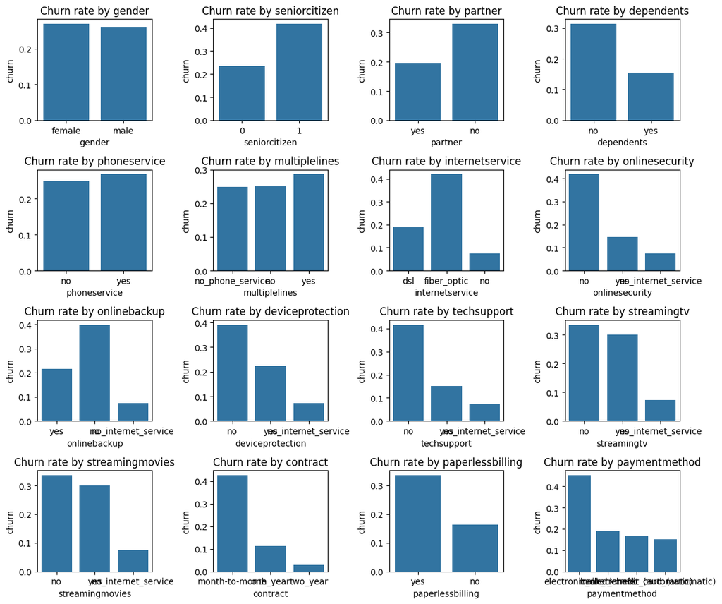

```python
# Visualizacion de diferencias en churn rate por variable categorica

fig, ax = plt.subplots(4,4, figsize=(12,10))

ax = ax.flatten()

for i, col in enumerate(data.select_dtypes(['object','category']).columns):
    sns.barplot(data=data,x=col,y='churn', ax=ax[i], errorbar=None)
    ax[i].set_title(f'Churn rate by {col}')

plt.tight_layout()
plt.show()
```

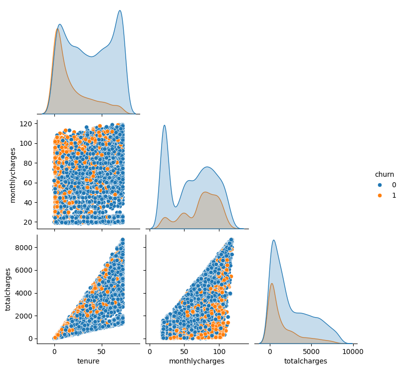

```python
# Distribuciones variables continuas
sns.pairplot(data, hue='churn', corner=True)
plt.show()
```

## Importancia de variables

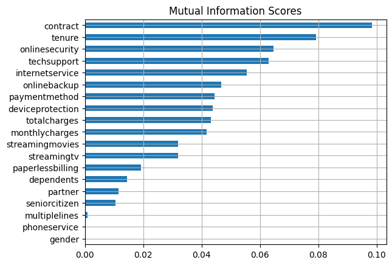

```python
X = data.drop('churn', axis=1)
y = data.churn

# Codificando variables categoricas
for colname in X.select_dtypes(["object",'category']):
    X[colname], _ = X[colname].factorize()

# Mutual information nos permite identidicar variables que explican mejor el modelo
# Es capaz de indentificar todo tipo de relaciones (no solo lineal)
from sklearn.feature_selection import mutual_info_classif

mutual_info_classif(X,y)

discrete_features = X.dtypes == int

def make_mi_scores(X, y, discrete_features):
    mi_scores = mutual_info_classif(X, y, discrete_features=discrete_features)
    mi_scores = pd.Series(mi_scores, name="MI Scores", index=X.columns)
    mi_scores = mi_scores.sort_values(ascending=True)
    return mi_scores

mi_scores = make_mi_scores(X, y, discrete_features)

mi_scores.plot(kind='barh', title='Mutual Information Scores', grid=True)
plt.show()
```

```python
# Otro enfoque valido para las varialbes continuas, sera hacer A/B test entre churn y no churn
# Descartamos si nivel de singificancia esta por sobre 5%
cols = ['tenure', 'monthlycharges', 'totalcharges']

for col in cols:
    _, p_value = stats.ttest_ind(data[data.churn==0][col], data[data.churn==1][col])
    print(f'{col} p_value = {p_value}')
```

```
tenure p_value = 7.99905796059022e-205
monthlycharges p_value = 2.7066456068884154e-60
totalcharges p_value = 2.127211613240394e-63
```

De lo anterior podemos observar que las variables que tienen una mayor diferencia de churn rate entre las categorias y distribuciones, tienden a ser mas improtantes en el modelo segun el MI score. Tambien validamos que las variables continuas si presentan diferencias estadisticamente significativas entre ambos grupos (p_value<0.05), esto quiere decir que es probable que separen bien los datos entre churn y no churn.

## Preprocessing

```python
X = data.drop('churn', axis=1)
y = data.churn
```

```python
# Acorde a lo anterior usaremos las top 6 variables para nuestro modelo
top6_features = mi_scores.sort_values(ascending=False)[:6].index

X = X[top6_features]

X.head()
```

|  | contract | tenure | onlinesecurity | techsupport | internetservice | onlinebackup |
| --- | --- | --- | --- | --- | --- | --- |
| 0 | month-to-month | 1 | no | no | dsl | yes |
| 1 | one_year | 34 | yes | no | dsl | no |
| 2 | month-to-month | 2 | yes | no | dsl | yes |
| 3 | one_year | 45 | yes | yes | dsl | no |
| 4 | month-to-month | 2 | no | no | fiber_optic | no |

```python
# Onehot encoding
X = pd.get_dummies(X, drop_first=True, dtype=int)

X.head()
```

|  | tenure | contract_one_year | contract_two_year | onlinesecurity_no_internet_service | onlinesecurity_yes | techsupport_no_internet_service | techsupport_yes | internetservice_fiber_optic | internetservice_no | onlinebackup_no_internet_service | onlinebackup_yes |
| --- | --- | --- | --- | --- | --- | --- | --- | --- | --- | --- | --- |
| 0 | 1 | 0 | 0 | 0 | 0 | 0 | 0 | 0 | 0 | 0 | 1 |
| 1 | 34 | 1 | 0 | 0 | 1 | 0 | 0 | 0 | 0 | 0 | 0 |
| 2 | 2 | 0 | 0 | 0 | 1 | 0 | 0 | 0 | 0 | 0 | 1 |
| 3 | 45 | 1 | 0 | 0 | 1 | 0 | 1 | 0 | 0 | 0 | 0 |
| 4 | 2 | 0 | 0 | 0 | 0 | 0 | 0 | 1 | 0 | 0 | 0 |